# Time constants

In the circuit shown in the figure, the switch is closed for a long time and opens at $t=0$. The current $i_1$ is $45\,$mA at $t=0.1\,$msec.

1. Find $V_C(0^-)$.
2. Using $V_C(0^+)=V_C(0^-)$, find $i_1(0^+)$.
3. Find $i_1(\infty)$.
4. Let $i_1(t)=A\,e^{-t/\tau} + B$ for $t > 0$. Using $i_1(0^+)$ and $i_1(\infty)$, find $A$ and $B$.
5. Obtain $\tau$ using the condition $i_1=45\,$mA at $t=0.1\,$msec.
6. From $\tau$, find $C$.

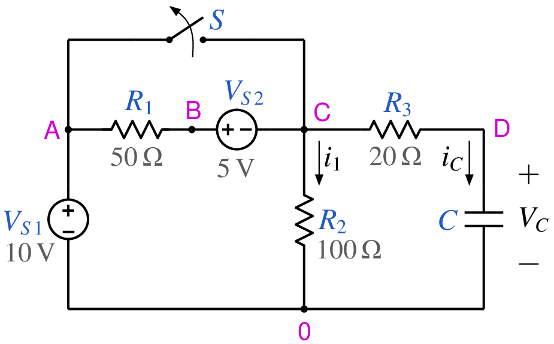

```python
from IPython.display import Image
Image(filename =r'time_constant_4_fig_1.png', width=350)
```

```python
# run this cell to view the circuit file.
%pycat time_constant_4_orig.in
```

We now replace the string \$C with the value of our choice by running the python script given below. It takes an existing circuit file `time_constant_4_orig.in` and produces a new circuit file `time_constant_4.in`, after replacing \$C with the value of our choice.

```python
import gseim_calc as calc
s_C = '0.8e-6' # to be changed by user
l = [
  ('$C', s_C),
]
calc.replace_strings_1("time_constant_4_orig.in", "time_constant_4.in", l)
print('time_constant_4.in is ready for execution')
```

```
time_constant_4.in is ready for execution
```

**Execute the following cell to run GSEIM on time_constant_4.in.**

```python
import os
import dos_unix
# uncomment for windows:
#dos_unix.d2u("time_constant_4.in")
os.system('run_gseim time_constant_4.in')
```

```
Circuit: filename = time_constant_4.in
main: i_solve = 1
main: calling solve_trns
Transient simulation starts...
i=0
GSEIM: Program completed.
```

```
0
```

The circuit file (`time_constant_4.in`) is created in the same directory as that used for launching Jupyter notebook. The last step (i.e., running `GSEIM` on `time_constant_4.in`) creates the data file `time_constant_4_1.dat`, etc. in the same directory. We can now use the python code below to compute and display the quantities of interest.

```
filename: time_constant_4_1.dat
filename: time_constant_4_2.dat
time points at which i1 crosses 45.0000 mA
    0.0544 msec
```

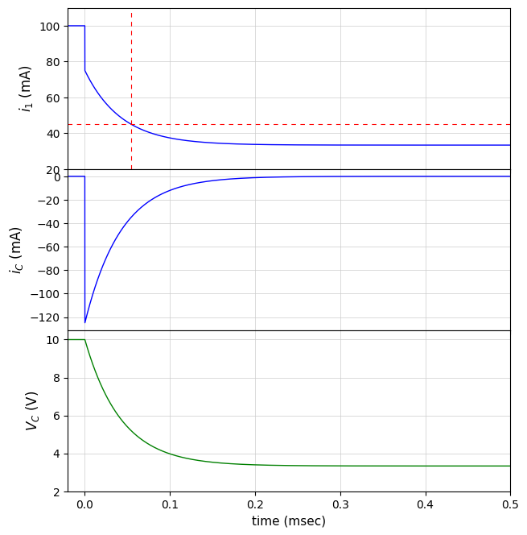

```python
import numpy as np
import matplotlib.pyplot as plt
import gseim_calc as calc
from setsize import set_size

slv = calc.slv("time_constant_4.in")

i_slv = 0
i_out = 0
filename = slv.l_filename_all[i_slv][i_out]
print('filename:', filename)
u = np.loadtxt(filename)

IR2_dc = slv.get_scalar_double(i_slv, i_out, 'IR2', u)
IC_dc  = slv.get_scalar_double(i_slv, i_out, 'IC',  u)
VC_dc  = slv.get_scalar_double(i_slv, i_out, 'VC',  u)

i_slv = 1
i_out = 0
filename = slv.l_filename_all[i_slv][i_out]
print('filename:', filename)
u = np.loadtxt(filename)

t = u[:, 0]
t_end = t[-1]
IR20 = 45.0e-3

IR2 = slv.get_array_double(i_slv, i_out, 'IR2', u)
IC  = slv.get_array_double(i_slv, i_out, 'IC',  u)
VC  = slv.get_array_double(i_slv, i_out, 'VC',  u)

ta = -0.02e-3
tb = 0.0
t_1 = np.array([ta, tb])
IR2_1 = np.array([IR2_dc, IR2_dc])
IC_1  = np.array([IC_dc,  IC_dc])
VC_1  = np.array([VC_dc,  VC_dc])

t_2   = np.concatenate((t_1,   t))
IR2_2 = np.concatenate((IR2_1, IR2))
IC_2  = np.concatenate((IC_1,  IC))
VC_2  = np.concatenate((VC_1,  VC))

l_cross_1, l_cross_2 = calc.cross_over_points_1(t, IR2, 0.0, t_end, IR20)
print('time points at which i1 crosses', "%7.4f"%(IR20*1.0e3), "mA")
for t1 in l_cross_2:
    print("  ", "%7.4f"%(t1*1e3), "msec")

color1='blue'
color2='green'
color3='red'

fig, ax = plt.subplots(3, sharex=False)
plt.subplots_adjust(wspace=0, hspace=0.0)

set_size(5.5, 6.0, ax[0])

for i in range(3):
    ax[i].set_xlim(left=ta*1e3, right=t_end*1e3)
    ax[i].grid(color='#CCCCCC', linestyle='solid', linewidth=0.5)

ax[0].set_ylim(bottom=20.0, top=110.0)
ax[2].set_ylim(bottom=2.0,  top=10.5)

ax[0].set_ylabel(r'$i_1$ (mA)', fontsize=12)
ax[1].set_ylabel(r'$i_C$ (mA)', fontsize=12)
ax[2].set_ylabel(r'$V_C$ (V)',  fontsize=12)

ax[0].tick_params(labelbottom=False)
ax[1].tick_params(labelbottom=False)

ax[0].plot(t_2*1e3, IR2_2*1e3, color=color1, linewidth=1.0, label="$i_1$")
ax[1].plot(t_2*1e3, IC_2*1e3,  color=color1, linewidth=1.0, label="$i_C$")
ax[2].plot(t_2*1e3, VC_2,      color=color2, linewidth=1.0, label="$V_C$")

ax[0].axhline(y = IR20*1e3, color = color3, linestyle = '--', linewidth=0.8, dashes=(5,5))
if len(l_cross_2) != 0:
    ax[0].axvline(x = l_cross_2[0]*1e3, color = color3, linestyle = '--', linewidth=0.8, dashes=(5,5))

ax[2].set_xlabel('time (msec)', fontsize=11)

#plt.tight_layout()
plt.show()
```

This notebook was contributed by **Prof. M. B. Patil**, IIT Bombay. He may be contacted at mbpatil@ee.iitb.ac.in.